# **Bellabeat Case Study**

# **Step 4: ANALYSE**

### **4.1 User Type Classification (calculating average steps, categorizing users)**

• Calculate average daily steps for each user.  
• Categorize users into ‘very active’, ‘fairly active’, ‘lightly active’, or ‘sedentary’ based on their average steps.

```r
Daily_Average <- Daily_Activity_Sleep %>%
  group_by(id) %>%
  summarise (mean_daily_steps = mean(totalsteps), mean_daily_calories = mean(calories), mean_daily_sleep = mean(totalminutesasleep))

Daily_Average <- Daily_Average %>%
  mutate(
    user_type = case_when(
      mean_daily_steps > 10000 ~ "very active",
      mean_daily_steps > 7500  ~ "fairly active",
      mean_daily_steps > 5000  ~ "lightly active",
      TRUE                     ~ "sedentary"
    )
  )
```

• Calculate the percentage of users in each activity category.

```r
user_type_percent <- Daily_Average %>%
  group_by(user_type) %>%
  summarise(user_count = n_distinct(id)) %>%
  mutate(percentage = paste0(round(100 * user_count / sum(user_count), 2), " %"))
```

```r
DT::datatable(
  head(user_type_percent),
  caption = "Table 1 : User Type with Percentage",
  width = "60%"
)
```

|  | user_type | user_count | percentage |
| --- | --- | --- | --- |
| 1 | fairly active | 9 | 37.5 % |
| 2 | lightly active | 5 | 20.83 % |
| 3 | sedentary | 5 | 20.83 % |
| 4 | very active | 5 | 20.83 % |

### **4.2 Hourly Steps Throughout The Day (analyzing activity patterns)**

```r
Hourly_Steps_summary <- Hourly_Steps %>%
  group_by(time) %>%
  summarize(average_steps = mean(steptotal))
```

```r
htmltools::div(
  style = "text-align:center;",
  DT::datatable(
    Hourly_Steps_summary,
    caption = "Table 2 : Hourly Steps (average)",
    width = "60%"
  ) %>%
    DT::formatRound('average_steps', 2) %>%
    DT::formatStyle(
      columns = 'average_steps',
      'text-align' = 'center'
    )
)
```

|  | time | average_steps |
| --- | --- | --- |
| 1 | 00:00:00 | 42.18843683083512 |
| 2 | 01:00:00 | 23.10289389067524 |
| 3 | 02:00:00 | 17.11039657020364 |
| 4 | 03:00:00 | 6.426580921757771 |
| 5 | 04:00:00 | 12.69957081545064 |
| 6 | 05:00:00 | 43.86909871244635 |
| 7 | 06:00:00 | 178.5080558539205 |
| 8 | 07:00:00 | 306.0494092373792 |
| 9 | 08:00:00 | 427.5445757250268 |
| 10 | 09:00:00 | 433.3018259935553 |

[output cut: 14 more lines]

### **4.3 Correlation (examining relationships of daily steps with daily sleep and calories)**

**Daily steps vs daily sleep Correlation Value**

```r
round(cor(Daily_Activity_Sleep$totalsteps, Daily_Activity_Sleep$totalminutesasleep, use = "complete.obs"), 2)
```

```
## [1] -0.19
```

**Daily steps vs calories Correlation Value**

```r
round(cor(Daily_Activity_Sleep$totalsteps, Daily_Activity_Sleep$calories, use = "complete.obs"), 2)
```

```
## [1] 0.41
```

### **4.4 Correlation (examining relationships of Calories with daily steps, total distance and daily sleep)**

**Daily steps vs calories Correlation Value**

```r
round(cor(Daily_Activity_Sleep$totalsteps, Daily_Activity_Sleep$calories, use = "complete.obs"), 2)
```

```
## [1] 0.41
```

**Total distance vs calories Correlation Value**

```r
round(cor(Daily_Activity_Sleep$totaldistance, Daily_Activity_Sleep$calories, use = "complete.obs"), 2)
```

```
## [1] 0.52
```

**Daily sleep vs Calories sleep Correlation Value**

```r
round(cor(Daily_Activity_Sleep$totalminutesasleep, Daily_Activity_Sleep$calories, use = "complete.obs"), 2)
```

```
## [1] -0.03
```

# **Step 5: SHARE**

### **Visualize Key Insights**

**5.1 User Type Classification**

*Pie chart for User Type Distribution*

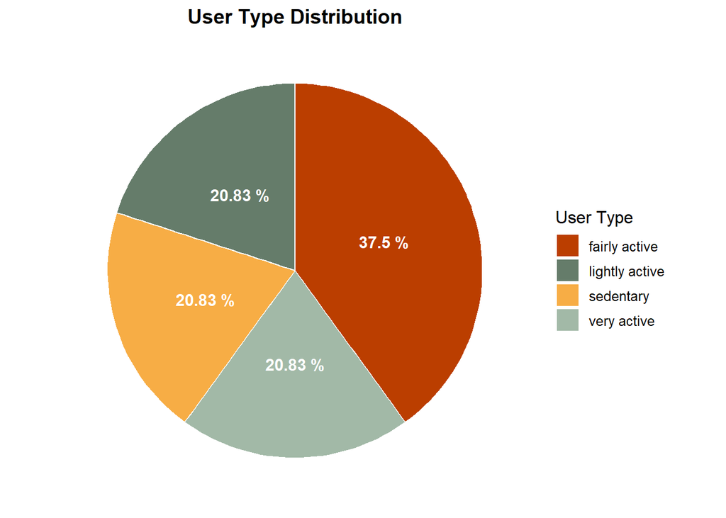

```r
user_type_percent %>%
  ggplot(aes(x = "", y = percentage, fill = user_type)) +
  geom_bar(stat = "identity", width = 1, color = "white") +
  coord_polar("y", start = 0) +
  theme_minimal(base_size = 12) +
  theme(
    axis.title.x = element_blank(),
    axis.title.y = element_blank(),
    panel.border = element_blank(),
    panel.grid = element_blank(),
    axis.ticks = element_blank(),
    axis.text.x = element_blank(),
    plot.title = element_text(hjust = 0.5, size = 14, face = "bold"),
    legend.position = "right"
  ) +
  scale_fill_manual(values = c("#BB3E00", "#657C6A", "#F7AD45", "#A2B9A7")) +
  geom_text(aes(label = percentage),
            position = position_stack(vjust = 0.5), size = 4, color = "white", fontface = "bold") +
  labs(title = "User Type Distribution", fill = "User Type")
```

**5.2 Hourly Steps Throughout The Day**